# Hw6

Getong Zhong

2022-10-17

## Part I

### Problem 1

#### (a)

```r
dec <- read.csv("C:/Users/tonyg/Desktop/Academic/Grad/HUDM 5026/decath.csv")
is.tibble(dec)
```

```
## [1] FALSE
```

It is not tibble since it print out more than 10 rows

#### (b)

```r
print(dec, max.levels = NULL, width = 300)
```

```
##     X100 long  poid haut  X400  X110  disq perc  jave  X1500
## 1  11.25 7.43 15.48 2.27 48.90 15.13 49.28  4.7 61.32 268.95
## 2  10.87 7.45 14.97 1.97 47.71 14.46 44.36  5.1 61.76 273.02
## 3  11.18 7.44 14.20 1.97 48.29 14.81 43.66  5.2 64.16 263.20
## 4  10.62 7.38 15.02 2.03 49.06 14.72 44.80  4.9 64.04 285.11
## 5  11.02 7.43 12.92 1.97 47.44 14.40 41.20  5.2 57.46 256.64
## 6  10.83 7.72 13.58 2.12 48.34 14.18 43.06  4.9 52.18 274.07
## 7  11.18 7.05 14.12 2.06 49.34 14.39 41.68  5.7 61.60 291.20
## 8  11.05 6.95 15.34 2.00 48.21 14.36 41.32  4.8 63.00 265.86
## 9  11.15 7.12 14.52 2.03 49.15 14.66 42.36  4.9 66.46 269.62
## 10 11.23 7.28 15.25 1.97 48.60 14.76 48.02  5.2 59.48 292.24
## 11 10.94 7.45 15.34 1.97 49.94 14.25 41.86  4.8 66.64 295.89
## 12 11.18 7.34 14.48 1.94 49.02 15.11 42.76  4.7 65.84 256.74
## 13 11.02 7.29 12.92 2.06 48.23 14.94 39.54  5.0 56.80 257.85
## 14 10.99 7.37 13.61 1.97 47.83 14.70 43.88  4.3 66.54 268.97
```

[output cut: 19 more lines]

### Problem 2

```r
apply(X = dec, MARGIN = 2, FUN = mean)
```

```
##       X100       long       poid       haut       X400       X110       disq
##  11.196364   7.133333  13.976364   1.982727  49.276667  15.048788  42.353939
##       perc       jave      X1500
##   4.739394  59.438788 276.038485
```

```r
apply(X = dec, MARGIN = 2, FUN = sd)
```

```
##       X100       long       poid       haut       X400       X110       disq
##  0.2433210  0.3043401  1.3319906  0.0939838  1.0696602  0.5067652  3.7191312
##       perc       jave      X1500
##  0.3344206  5.4959984 13.6570975
```

### Problem 3

```r
cov(dec)
```

```
##               X100        long        poid         haut         X400
## X100   0.059205114 -0.03995625 -0.06740426 -0.003336648  0.157696875
## long  -0.039956250  0.09262292  0.05752187  0.007812500 -0.167760417
## poid  -0.067404261  0.05752187  1.77419886  0.015282102  0.134759375
## haut  -0.003336648  0.00781250  0.01528210  0.008832955 -0.008796875
## X400   0.157696875 -0.16776042  0.13475938 -0.008796875  1.144172917
## X110   0.078714205 -0.07372083 -0.19961080 -0.014609091  0.295983333
## disq  -0.042735227  0.04745208  3.99454602  0.051529545  0.565654167
## perc  -0.031664773  0.03561458  0.21380398  0.006701705 -0.113989583
## jave  -0.086542045  0.30386667  4.37533295  0.059884659  0.707533333
## X1500  0.867431818 -1.64421667  4.89030994 -0.146436364  8.579279167
##              X110        disq         perc        jave       X1500
## X100   0.07871420 -0.04273523 -0.031664773 -0.08654205   0.8674318
## long  -0.07372083  0.04745208  0.035614583  0.30386667  -1.6442167
## poid  -0.19961080  3.99454602  0.213803977  4.37533295   4.8903099
## haut  -0.01460909  0.05152955  0.006701705  0.05988466  -0.1464364
## X400   0.29598333  0.56565417 -0.113989583  0.70753333   8.5792792
## X110   0.25681098 -0.20825758 -0.088388258 -0.17497027   0.9917544
## disq  -0.20825758 13.83193712  0.427808712  9.05317992  20.4348530
## perc  -0.08838826  0.42780871  0.111837121  0.50404924  -0.1438447
## jave  -0.17497027  9.05317992  0.504049242 30.20599848   7.2338981
## X1500  0.99175436 20.43485303 -0.143844697  7.23389811 186.5163133
```

```r
round(cor(dec),2)
```

```
##        X100  long  poid  haut  X400  X110  disq  perc  jave X1500
## X100   1.00 -0.54 -0.21 -0.15  0.61  0.64 -0.05 -0.39 -0.06  0.26
## long  -0.54  1.00  0.14  0.27 -0.52 -0.48  0.04  0.35  0.18 -0.40
## poid  -0.21  0.14  1.00  0.12  0.09 -0.30  0.81  0.48  0.60  0.27
## haut  -0.15  0.27  0.12  1.00 -0.09 -0.31  0.15  0.21  0.12 -0.11
## X400   0.61 -0.52  0.09 -0.09  1.00  0.55  0.14 -0.32  0.12  0.59
## X110   0.64 -0.48 -0.30 -0.31  0.55  1.00 -0.11 -0.52 -0.06  0.14
## disq  -0.05  0.04  0.81  0.15  0.14 -0.11  1.00  0.34  0.44  0.40
## perc  -0.39  0.35  0.48  0.21 -0.32 -0.52  0.34  1.00  0.27 -0.03
## jave  -0.06  0.18  0.60  0.12  0.12 -0.06  0.44  0.27  1.00  0.10
## X1500  0.26 -0.40  0.27 -0.11  0.59  0.14  0.40 -0.03  0.10  1.00
```

From the correlation matrice above we can see for X100 it has a pairwise correlation with long, X400, and X110 for a absolute value over 0.5, for long it has a high correlation when pair with long X100 and X400 as well. I think these pairwise correlation kind of make sense to me. Because X100, X400 amd X110 are all mid and short distance so it is not suprise that they have a strong positive corelation with each other, and for long jump it is a totally different sport so it is not suprise that it has a strong negative correlation with the speeding games. ### Problem 4

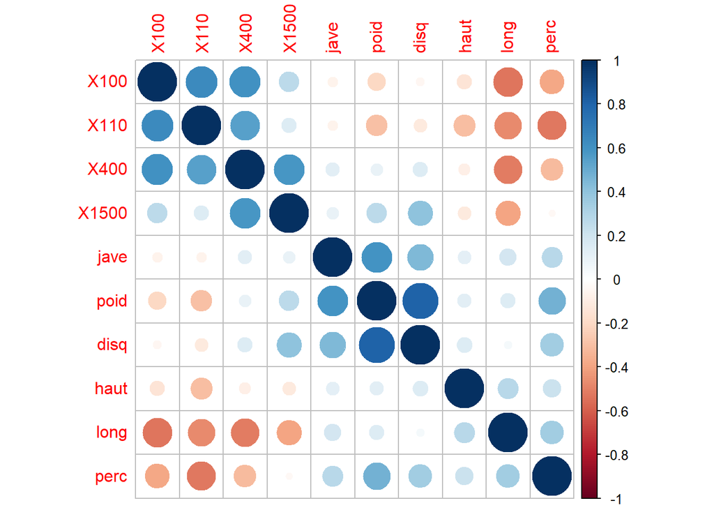

```r
library(corrplot)
corrplot(cor(dec), order = "hclust")
```

Disq (discus throw) and poid (shotput) are pretty similar games which require athelet to have a great strength, and even this the similar rules that the are competing how far you can throw/push the heavy ball/discus , so it is make sense that they are inter-correlated .

### Problem 5

#### (a)

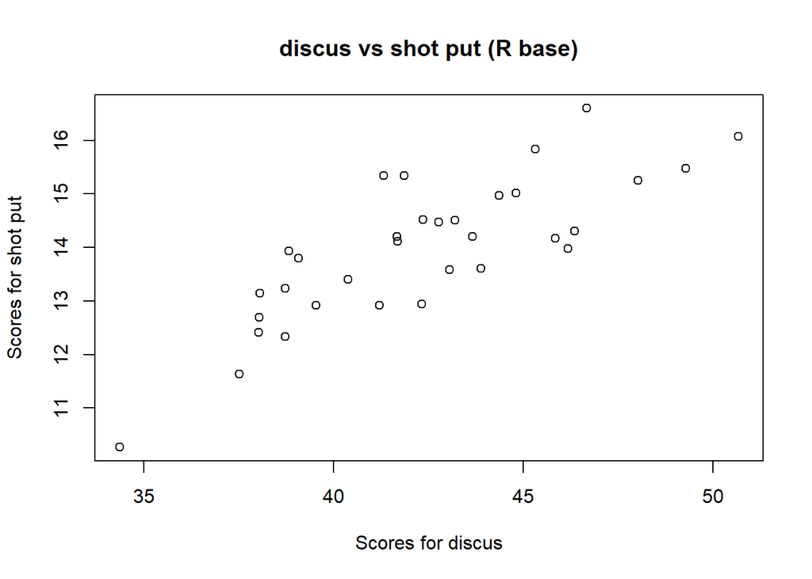

```r
plot(dec$disq, dec$poid, main = "discus vs shot put (R base)",
     xlab = "Scores for discus",
     ylab = "Scores for shot put")
```

#### (b)

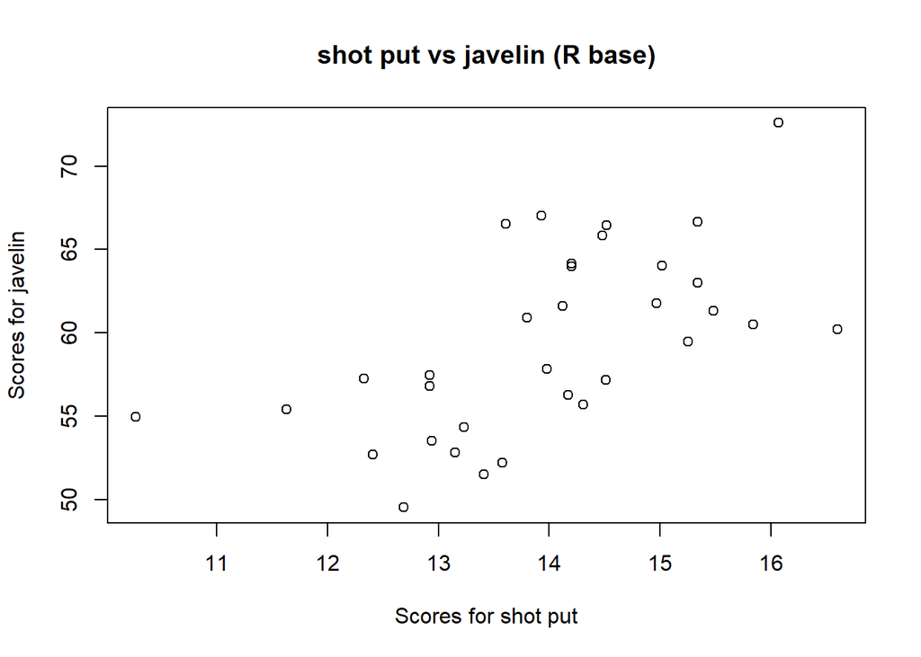

```r
plot(dec$poid, dec$jave, main = "shot put vs javelin (R base)",
     xlab = "Scores for shot put",
     ylab = "Scores for javelin")
```

#### (c)

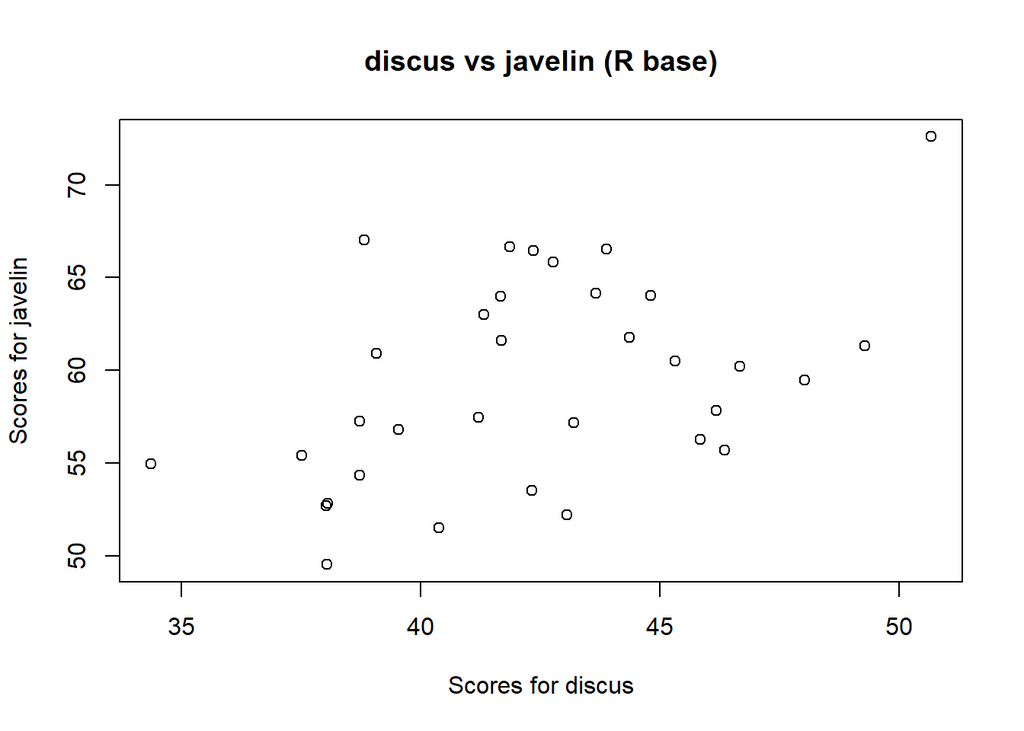

```r
plot(dec$disq, dec$jave, main = "discus vs javelin (R base)",
     xlab = "Scores for discus",
     ylab = "Scores for javelin")
```

#### (d)

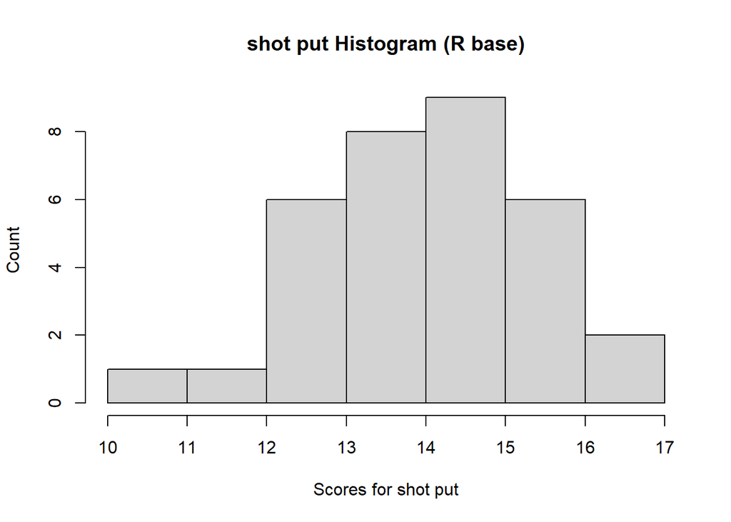

```r
hist(dec$poid, main = "shot put Histogram (R base)",
     xlab = "Scores for shot put",
     ylab = "Count")
```

### Problem 6

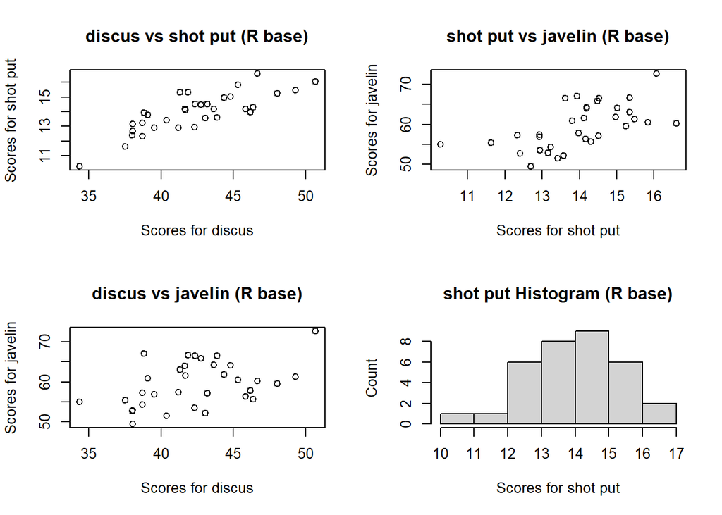

```r
par(mfrow = c(2,2))
plot(dec$disq, dec$poid, main = "discus vs shot put (R base)",
     xlab = "Scores for discus",
     ylab = "Scores for shot put")
plot(dec$poid, dec$jave, main = "shot put vs javelin (R base)",
     xlab = "Scores for shot put",
     ylab = "Scores for javelin")
plot(dec$disq, dec$jave, main = "discus vs javelin (R base)",
     xlab = "Scores for discus",
     ylab = "Scores for javelin")
hist(dec$poid, main = "shot put Histogram (R base)",
     xlab = "Scores for shot put",
     ylab = "Count")
```

### Problem 7

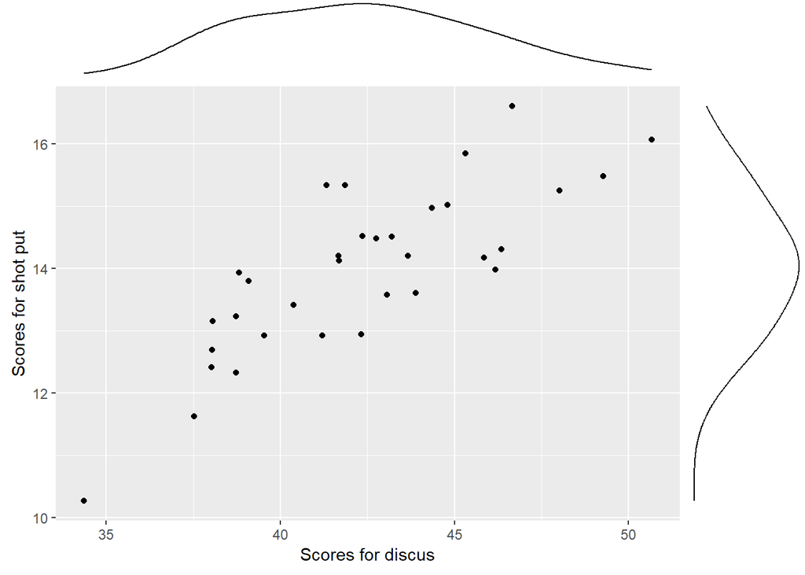

```r
p1 <- ggplot(data = dec, mapping = aes(x = disq, y = poid)) +
  geom_point() +
  xlab("Scores for discus") +
  ylab("Scores for shot put") +
  theme(legend.position = "none")


ggMarginal(p1, type = "density")
```

## Part II

### Problem 1

```r
acu <- read.csv("C:/Users/tonyg/Desktop/Academic/Grad/HUDM 5026/acupuncture.csv", header = TRUE)
```

### Problem 2

```r
acu2 <- acu[
  order(acu$group, acu$sex, acu$age),
]
```

### Problem 3

```r
acu3 <- subset(acu, group == 1 & age > 30)
```

### Problem 4

```r
fourty_percentile <- quantile(acu$pk1, c(0.4))

acu4 <- subset(acu, pk1 >= fourty_percentile)
```

### Problem 5

```r
acu[which(acu$sex == 1 & acu$age >= 40), ]
```

```
##      id age sex migraine chronicity acupuncturist group   pk1      pk5
## 2   108  56   1        1         40             9     0 16.50 23.25000
## 3   112  45   1        1         27             9     1  9.25  6.25000
## 4   113  45   1        1         30             9     1 42.50 51.25000
## 5   114  49   1        1         49             9     1 24.25 25.25000
## 6   126  47   1        1         42             5     0 21.00 15.25000
## 7   130  46   1        1          3             7     1 21.75  1.00000
## 8   131  64   1        1         23             7     1 14.50  2.50000
## 9   135  59   1        1         40             7     0 40.50 28.75000
## 10  137  53   1        1         32             7     1 11.75 13.50000
## 13  144  49   1        1         10             7     0 39.50 40.00000
## 14  148  55   1        1         20             2     0 20.50 32.75000
## 16  150  59   1        1         54             2     1  9.75 21.50000
## 18  162  47   1        1          4             5     0 14.50 12.50000
## 19  169  49   1        1         40             5     1 19.75 18.75000
```

[output cut: 181 more lines]